# Mileston Project

Kleanthis Mazarakis

January 5, 2018

# Introduction

The Coursera Data Science Capstone involves predictive text analytics. The overall objective is to help users complete sentences by analyzing the words they have entered and predicating the next word.

The purpose of this Milestone Report is to demonstrate progress towards the end goal of this project. The specific sections are as follows:

- Load/Profile Raw Data - demonstrate progress with loading the data into R & profiling the raw data
- Create Sample Corpus - prepare the data prior to NLP
- Create N-grams to Explore Data - create n-grams & explore the word patterns
- Next Steps - discuss plans for creating the prediction algorighm & shiny application

# Load the Data and do some summary Statistics

```r
library(stringi)
library(tm)
```

```r
library(RWeka)
library(ggplot2)
twitter <- readLines("en_US.twitter.txt")
news <- readLines("en_US.news.txt")
blogs <- readLines("en_US.blogs.txt")
```

In the next step we are counting the number of lines and the number of words in each of our datasets

```r
#Number of lines
paste("We have ", length(twitter), "lines in the twitter dataset")
```

```
## [1] "We have  2360148 lines in the twitter dataset"
```

```r
paste("We have ", length(news), "lines in the news dataset")
```

```
## [1] "We have  77259 lines in the news dataset"
```

```r
paste("We have ", length(blogs), "lines in the blogs dataset")
```

```
## [1] "We have  899288 lines in the blogs dataset"
```

```r
#Number of words
paste("We have ", sum(stri_count_words(twitter)), "words in the twitter dataset")
```

```
## [1] "We have  30218125 words in the twitter dataset"
```

```r
paste("We have ", sum(stri_count_words(news)), "words in the news dataset")
```

```
## [1] "We have  2693898 words in the news dataset"
```

```r
paste("We have ", sum(stri_count_words(blogs)), "words in the blogs dataset")
```

```
## [1] "We have  38154238 words in the blogs dataset"
```

In the next step we are going to randomly sample our datasets in order to get a smaller dataset that we can work with

# Create Sample dataset and Corpus file

```r
#Sample lines from each file
twitter_sample <- sample(twitter, 1000) #length(twitter)*0.01)
news_sample <- sample(news, 1000) #length(news)*0.01)
blogs_sample <- sample(blogs, 1000) #length(blogs)*0.01)

length(twitter_sample)
```

```
## [1] 1000
```

```r
length(news_sample)
```

```
## [1] 1000
```

```r
length(blogs_sample)
```

```
## [1] 1000
```

```r
alldata_sample <- c(twitter_sample, news_sample, blogs_sample)

corpus_sample <- VCorpus(VectorSource(alldata_sample))
#Placeholder for potentially removing stopwods at later stage
##corpus_sample <- tm_map(corpus_sample, removeWords, stopwords("en"))
corpus_sample <- tm_map(corpus_sample, removeNumbers)
corpus_sample <- tm_map(corpus_sample, stripWhitespace)
corpus_sample <- tm_map(corpus_sample, content_transformer(tolower))
corpus_sample <- tm_map(corpus_sample, removePunctuation)
text_corpus <- data.frame(text = unlist(sapply(corpus_sample, `[`, "content")), stringsAsFactors = F)
text_corpus[1:5,]
```

```
## [1] "does anyone have a contact at toys for tots weve emailed and left a bagillion messages but no one is getting back to us "
## [2] "im not perfect "
## [3] "any niggah that watch you up and down want something you got"
## [4] "new aaron rodgers state farm ad debuts this weekend lets hope it wont be as irritating as the first"
## [5] "bouta go to the chinese buffet  with my sis   yea "
```

# Data Exploration with Ngrams

```r
unigrams <- NGramTokenizer(text_corpus, Weka_control(min=1, max=1))
bigrams <- NGramTokenizer(text_corpus, Weka_control(min=2, max=2))
trigrams <- NGramTokenizer(text_corpus, Weka_control(min=3, max=3))
quadgrams <- NGramTokenizer(text_corpus, Weka_control(min=4, max=4))

unigrams_table <- data.frame(table(unigrams))
bigrams_table <- data.frame(table(bigrams))
trigrams_table <- data.frame(table(trigrams))
quadgrams_table <- data.frame(table(quadgrams))

unigrams_table_top20 <- head(unigrams_table[order(unigrams_table$Freq, decreasing = T),],20)
bigrams_table_top20 <- head(bigrams_table[order(bigrams_table$Freq, decreasing = T),],20)
trigrams_table_top20 <- head(trigrams_table[order(trigrams_table$Freq, decreasing = T),],20)
quadgrams_table_top20 <- head(quadgrams_table[order(quadgrams_table$Freq, decreasing = T),],20)

unigrams_table_top20
```

```
##       unigrams Freq
## 12711      the 4349
## 12905       to 2432
## 660        and 2265
## 1            a 2116
## 8835        of 1848
## 6382        in 1449
## 6265         i 1305
## 6668        is  923
## 5034       for  905
## 12702     that  890
## 6688        it  773
## 8907        on  743
## 14233      you  659
## 14025     with  636
## 13761      was  590
## 8430        my  480
## 967         at  465
## 12785     this  457
## 1299        be  452
## 897         as  449
```

```r
bigrams_table_top20
```

```
##        bigrams Freq
## 35608   of the  396
## 25536   in the  368
## 53892   to the  207
## 36281   on the  190
## 18981  for the  169
## 53158    to be  143
## 4616   and the  138
## 6292    at the  133
## 25045     in a  115
## 58906 with the  114
## 27053   it was   97
## 19656 from the   94
## 4053     and i   87
## 24403   i have   87
## 26305     is a   84
## 58438  will be   78
## 58677   with a   77
## 18643    for a   76
## 34854     of a   72
## 20698 going to   71
```

```r
trigrams_table_top20
```

```
##             trigrams Freq
## 938         a lot of   33
## 49493     one of the   24
## 8507      as well as   20
## 65545     the end of   18
## 26630    going to be   16
## 31929      i have to   16
## 63575 thanks for the   16
## 31886       i have a   15
## 71208        to be a   15
## 10070     be able to   13
## 103         a bit of   12
## 32390      i want to   12
## 32394    i wanted to   12
## 35563    is going to   12
## 51386    part of the   12
## 328      a couple of   11
## 60285    some of the   11
## 69078     there is a   11
## 20921     end of the   10
## 49491      one of my   10
```

```r
quadgrams_table_top20
```

```
##                     quadgrams Freq
## 67936          the end of the    8
## 69926         the rest of the    7
## 9423            at the end of    6
## 25042      for the first time    6
## 9485         at the same time    5
## 35507        in the middle of    5
## 65821   thanks for the follow    5
## 105                a bit of a    4
## 8532           as a result of    4
## 27441           going to be a    4
## 33715         i would like to    4
## 35648    in the united states    4
## 4061         all the way down    3
## 8736             as much as i    3
## 9506     at the university of    3
## 14028           by the end of    3
## 22271 every member of godâs    3
## 25854           from am to pm    3
## 31909         hope to see you    3
## 33063          i just want to    3
```

### Top 20 Unigrams

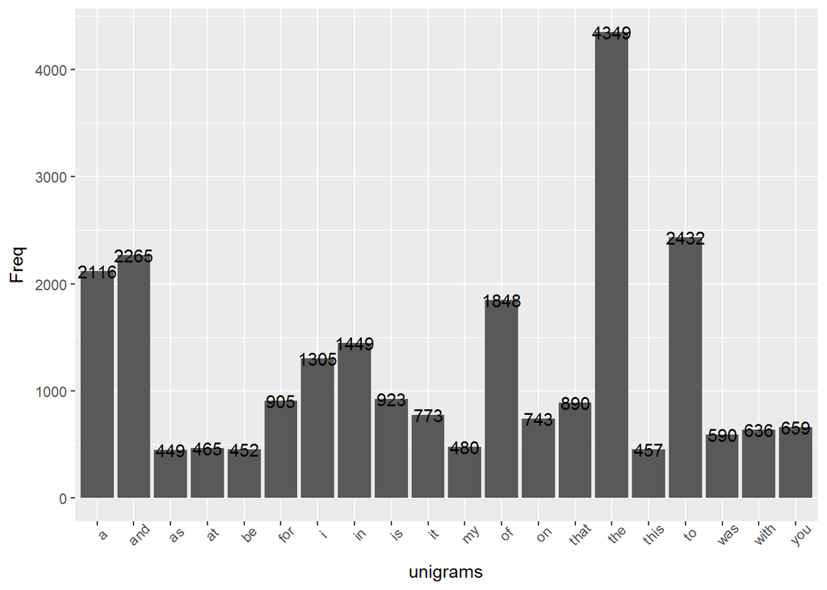

```r
ggplot(unigrams_table_top20, aes(x=unigrams, y=Freq)) + geom_bar(stat = "Identity") + geom_text(aes(label=Freq)) + theme(axis.text.x = element_text(angle = 45))
```

### Top 20 Bigrams

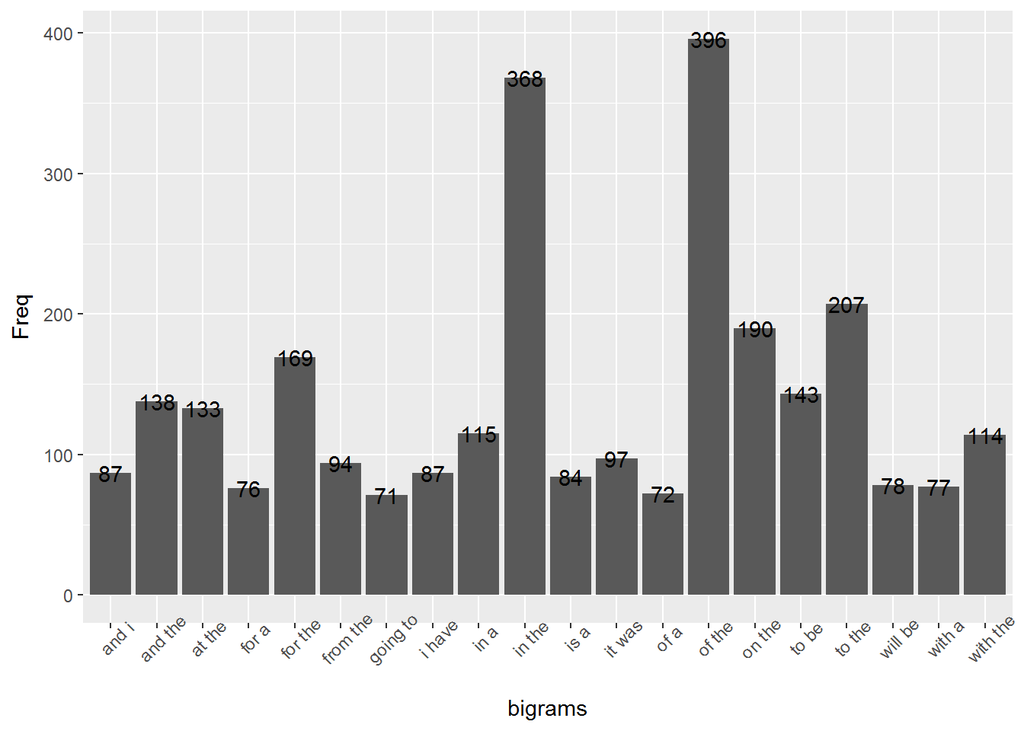

```r
ggplot(bigrams_table_top20, aes(x=bigrams, y=Freq)) + geom_bar(stat = "Identity") + geom_text(aes(label=Freq)) + theme(axis.text.x = element_text(angle = 45))
```

### Top 20 Trigrams

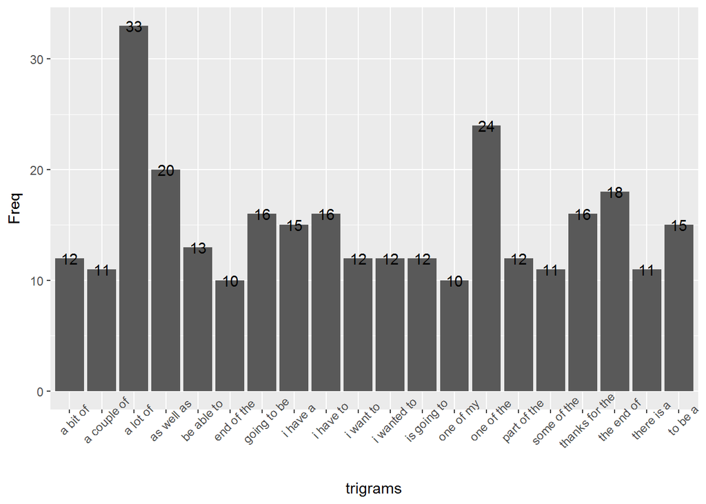

```r
ggplot(trigrams_table_top20, aes(x=trigrams, y=Freq)) + geom_bar(stat = "Identity") + geom_text(aes(label=Freq)) + theme(axis.text.x = element_text(angle = 45))
```

### Top 20 Quadgrams

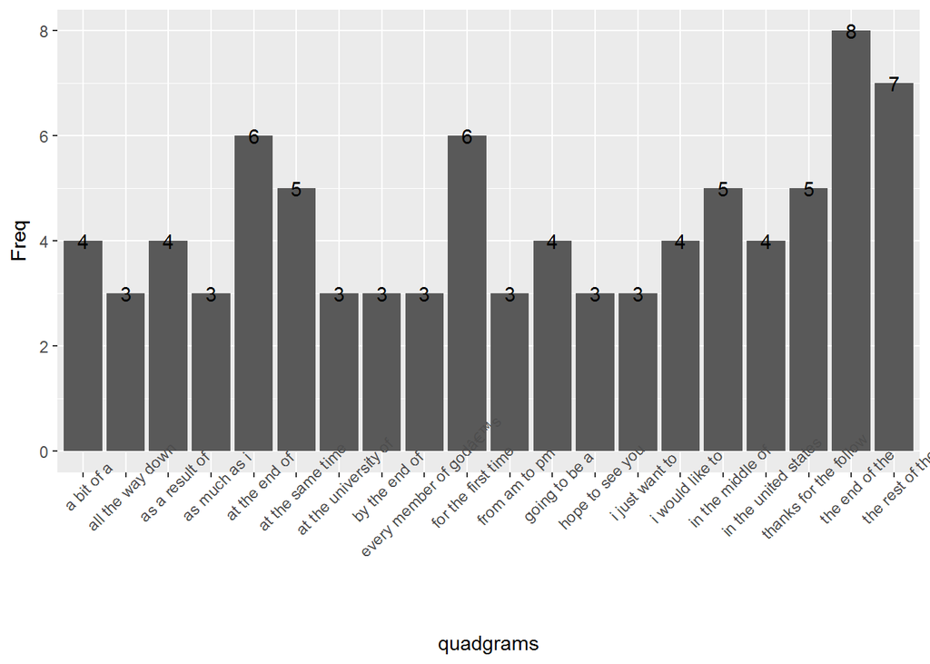

```r
ggplot(quadgrams_table_top20, aes(x=quadgrams, y=Freq)) + geom_bar(stat = "Identity") + geom_text(aes(label=Freq)) + theme(axis.text.x = element_text(angle = 45))
```

# Next Steps

The next step of this project will be to build our predicting algorithm and deploy it as a Shiny application. Our strategy for building the algorithm will potentially be to use the trigrams created in the above analysis in order to predict the next word. If there is no match for the trigram, then the algorithm would fall back to using the bigrams and the unigrams as a last resort. In the final step of the project we will also need to take account of the time required for the prediction, since our model should be responsive in “real time”.